# Wilkins Ramp-Down Tool: Mathematical Formulation

USACE – Wilkins Spillway Ramp-Down Team

2026-09-23

## 1. Purpose and linkage to the app

This document walks through the equations behind the **Wilkins Spillway ramp‑down dashboard**, using the same math as the Shiny application but in a static, reproducible format. It is intended to:

- Make the ramp‑down logic transparent to operators, biologists, and reviewers.
- Provide a reference that can be updated alongside the code when spillway tables or capacity curves change.
- Allow verification of outputs for specific test scenarios without connecting to live USGS data.

Where the live app pulls real‑time data from USGS Water Data APIs through the `dataRetrieval` package, this report uses simple example values to illustrate calculations.

## 2. Core inputs and lookup tables

### 2.1 Spillway gate step table

The Shiny app encodes Wilkins Spillway operations as discrete “steps” describing which gates are open, and uses a lookup table to relate each step to discharge across a range of tailwater elevations.

```r
gate_keys <- paste0("GATE_", 1:11)

# Read the full 1–177 step table from CSV
gate_schedule_lookup <- readr::read_csv(
  "data/wilkins_spillway_step_table.csv",
  na = c("", "NA")
)

# (Optional) add explicit Step 0 = all closed
gate_schedule_lookup <- dplyr::bind_rows(
  tibble::tibble(
    STEP      = 0L,
    GATE_1    = 0, GATE_2 = 0, GATE_3 = 0, GATE_4 = 0, GATE_5 = 0,
    GATE_6    = 0, GATE_7 = 0, GATE_8 = 0, GATE_9 = 0, GATE_10 = 0, GATE_11 = 0,
    D_215_230 = 0, D_220_230 = 0, D_225_230 = 0,
    D_230     = 0, D_235   = 0, D_240   = 0, D_244   = 0
  ),
  gate_schedule_lookup
)

dplyr::glimpse(gate_schedule_lookup)
```

```
## Rows: 185
## Columns: 19
## $ STEP      <dbl> 0, 1, 2, 3, 4, 5, 6, 7, 8, 9, 10, 11, 12, 13, 14, 15, 16, 17…
## $ GATE_1    <dbl> 0.00, 0.25, 0.50, 0.50, 0.50, 0.50, 0.50, 0.50, 0.50, 0.50, …
## $ GATE_2    <dbl> 0.0, 0.0, 0.0, 0.0, 0.0, 0.0, 0.0, 0.0, 0.5, 0.5, 0.5, 0.5, …
## $ GATE_3    <dbl> 0.0, 0.0, 0.0, 0.5, 0.5, 0.5, 0.5, 0.5, 0.5, 0.5, 0.5, 0.5, …
## $ GATE_4    <dbl> 0.0, 0.0, 0.0, 0.0, 0.0, 0.0, 0.0, 0.0, 0.0, 0.5, 0.5, 0.5, …
## $ GATE_5    <dbl> 0.0, 0.0, 0.0, 0.0, 0.5, 0.5, 0.5, 0.5, 0.5, 0.5, 0.5, 0.5, …
## $ GATE_6    <dbl> 0.0, 0.0, 0.0, 0.0, 0.0, 0.0, 0.0, 0.0, 0.0, 0.0, 0.5, 0.5, …
## $ GATE_7    <dbl> 0.0, 0.0, 0.0, 0.0, 0.0, 0.5, 0.5, 0.5, 0.5, 0.5, 0.5, 0.5, …
## $ GATE_8    <dbl> 0.0, 0.0, 0.0, 0.0, 0.0, 0.0, 0.0, 0.0, 0.0, 0.0, 0.0, 0.5, …
## $ GATE_9    <dbl> 0.0, 0.0, 0.0, 0.0, 0.0, 0.0, 0.5, 0.5, 0.5, 0.5, 0.5, 0.5, …
## $ GATE_10   <dbl> 0.0, 0.0, 0.0, 0.0, 0.0, 0.0, 0.0, 0.0, 0.0, 0.0, 0.0, 0.0, …
## $ GATE_11   <dbl> 0.0, 0.0, 0.0, 0.0, 0.0, 0.0, 0.0, 0.5, 0.5, 0.5, 0.5, 0.5, …
## $ D_215_230 <dbl> 0, 230, 466, 932, 1398, NA, NA, NA, NA, NA, NA, NA, NA, NA, …
## $ D_220_230 <dbl> 0, NA, NA, NA, NA, 1865, 2331, 2797, 3263, 3729, 4195, NA, N…
## $ D_225_230 <dbl> 0, NA, NA, NA, NA, NA, NA, NA, NA, NA, NA, 4662, 5128, 5587,…
## $ D_230     <dbl> 0, NA, NA, NA, NA, NA, NA, NA, NA, NA, NA, NA, NA, NA, NA, N…
## $ D_235     <dbl> 0.0, 216.5, 433.0, 867.0, 1301.0, 1734.0, 2168.0, 2601.0, 30…
## $ D_240     <dbl> 0, 154, 308, 617, 925, 1234, 1542, 1851, 2159, 2468, 2776, 3…
## $ D_244     <dbl> 0, 70, 140, 281, 421, 562, 702, 843, 983, 1124, 1264, 1405, …
```

```r
gate_schedule_lookup_gate <- gate_schedule_lookup %>%
  select(STEP, all_of(gate_keys))

gate_schedule_lookup_gate %>%
  kable(
    format  = "html",
    caption = "Wilkins Spillway gate openings (ft) by operational step",
    digits  = 2
  ) %>%
  kable_styling(
    bootstrap_options = c("striped", "condensed", "hover"),
    full_width = FALSE,
    position   = "left",
    font_size  = 11
  )
```

Wilkins Spillway gate openings (ft) by operational step

| STEP | GATE_1 | GATE_2 | GATE_3 | GATE_4 | GATE_5 | GATE_6 | GATE_7 | GATE_8 | GATE_9 | GATE_10 | GATE_11 |
| --- | --- | --- | --- | --- | --- | --- | --- | --- | --- | --- | --- |
| 0 | 0.00 | 0.0 | 0.0 | 0.0 | 0.0 | 0.0 | 0.0 | 0.0 | 0.0 | 0.0 | 0.0 |
| 1 | 0.25 | 0.0 | 0.0 | 0.0 | 0.0 | 0.0 | 0.0 | 0.0 | 0.0 | 0.0 | 0.0 |
| 2 | 0.50 | 0.0 | 0.0 | 0.0 | 0.0 | 0.0 | 0.0 | 0.0 | 0.0 | 0.0 | 0.0 |
| 3 | 0.50 | 0.0 | 0.5 | 0.0 | 0.0 | 0.0 | 0.0 | 0.0 | 0.0 | 0.0 | 0.0 |
| 4 | 0.50 | 0.0 | 0.5 | 0.0 | 0.5 | 0.0 | 0.0 | 0.0 | 0.0 | 0.0 | 0.0 |
| 5 | 0.50 | 0.0 | 0.5 | 0.0 | 0.5 | 0.0 | 0.5 | 0.0 | 0.0 | 0.0 | 0.0 |
| 6 | 0.50 | 0.0 | 0.5 | 0.0 | 0.5 | 0.0 | 0.5 | 0.0 | 0.5 | 0.0 | 0.0 |
| 7 | 0.50 | 0.0 | 0.5 | 0.0 | 0.5 | 0.0 | 0.5 | 0.0 | 0.5 | 0.0 | 0.5 |
| 8 | 0.50 | 0.5 | 0.5 | 0.0 | 0.5 | 0.0 | 0.5 | 0.0 | 0.5 | 0.0 | 0.5 |
| 9 | 0.50 | 0.5 | 0.5 | 0.5 | 0.5 | 0.0 | 0.5 | 0.0 | 0.5 | 0.0 | 0.5 |
| 10 | 0.50 | 0.5 | 0.5 | 0.5 | 0.5 | 0.5 | 0.5 | 0.0 | 0.5 | 0.0 | 0.5 |
| 11 | 0.50 | 0.5 | 0.5 | 0.5 | 0.5 | 0.5 | 0.5 | 0.5 | 0.5 | 0.0 | 0.5 |
| 12 | 0.50 | 0.5 | 0.5 | 0.5 | 0.5 | 0.5 | 0.5 | 0.5 | 0.5 | 0.5 | 0.5 |
| 13 | 1.00 | 0.5 | 0.5 | 0.5 | 0.5 | 0.5 | 0.5 | 0.5 | 0.5 | 0.5 | 0.5 |
| 14 | 1.00 | 0.5 | 1.0 | 0.5 | 0.5 | 0.5 | 0.5 | 0.5 | 0.5 | 0.5 | 0.5 |
| 15 | 1.00 | 0.5 | 1.0 | 0.5 | 1.0 | 0.5 | 0.5 | 0.5 | 0.5 | 0.5 | 0.5 |
| 16 | 1.00 | 0.5 | 1.0 | 0.5 | 1.0 | 0.5 | 1.0 | 0.5 | 0.5 | 0.5 | 0.5 |
| 17 | 1.00 | 0.5 | 1.0 | 0.5 | 1.0 | 0.5 | 1.0 | 0.5 | 1.0 | 0.5 | 0.5 |
| 18 | 1.00 | 0.5 | 1.0 | 0.5 | 1.0 | 0.5 | 1.0 | 0.5 | 1.0 | 0.5 | 1.0 |
| 19 | 1.00 | 1.0 | 1.0 | 0.5 | 1.0 | 0.5 | 1.0 | 0.5 | 1.0 | 0.5 | 1.0 |
| 20 | 1.00 | 1.0 | 1.0 | 1.0 | 1.0 | 0.5 | 1.0 | 0.5 | 1.0 | 0.5 | 1.0 |
| 21 | 1.00 | 1.0 | 1.0 | 1.0 | 1.0 | 1.0 | 1.0 | 0.5 | 1.0 | 0.5 | 1.0 |
| 22 | 1.00 | 1.0 | 1.0 | 1.0 | 1.0 | 1.0 | 1.0 | 1.0 | 1.0 | 0.5 | 1.0 |
| 23 | 1.00 | 1.0 | 1.0 | 1.0 | 1.0 | 1.0 | 1.0 | 1.0 | 1.0 | 1.0 | 1.0 |
| 24 | 1.50 | 1.0 | 1.0 | 1.0 | 1.0 | 1.0 | 1.0 | 1.0 | 1.0 | 1.0 | 1.0 |
| 25 | 1.50 | 1.0 | 1.5 | 1.0 | 1.0 | 1.0 | 1.0 | 1.0 | 1.0 | 1.0 | 1.0 |
| 26 | 1.50 | 1.0 | 1.5 | 1.0 | 1.5 | 1.0 | 1.0 | 1.0 | 1.0 | 1.0 | 1.0 |
| 27 | 1.50 | 1.0 | 1.5 | 1.0 | 1.5 | 1.0 | 1.5 | 1.0 | 1.0 | 1.0 | 1.0 |
| 28 | 1.50 | 1.0 | 1.5 | 1.0 | 1.5 | 1.0 | 1.5 | 1.0 | 1.5 | 1.0 | 1.0 |
| 29 | 1.50 | 1.0 | 1.5 | 1.0 | 1.5 | 1.0 | 1.5 | 1.0 | 1.5 | 1.0 | 1.5 |

[output cut: 155 more lines]

```r
gate_schedule_lookup_discharge <- gate_schedule_lookup %>%
  select(STEP, D_215_230, D_230, D_235, D_240, D_244)

gate_schedule_lookup_discharge %>%
  kable(
    format  = "html",
    caption = "Wilkins Spillway discharge (cfs) by step and tailwater band",
    digits  = 0
  ) %>%
  kable_styling(
    bootstrap_options = c("striped", "condensed", "hover"),
    full_width = FALSE,
    position   = "left",
    font_size  = 11
  )
```

Wilkins Spillway discharge (cfs) by step and tailwater band

| STEP | D_215_230 | D_230 | D_235 | D_240 | D_244 |
| --- | --- | --- | --- | --- | --- |
| 0 | 0 | 0 | 0 | 0 | 0 |
| 1 | 230 | NA | 216 | 154 | 70 |
| 2 | 466 | NA | 433 | 308 | 140 |
| 3 | 932 | NA | 867 | 617 | 281 |
| 4 | 1398 | NA | 1301 | 925 | 421 |
| 5 | NA | NA | 1734 | 1234 | 562 |
| 6 | NA | NA | 2168 | 1542 | 702 |
| 7 | NA | NA | 2601 | 1851 | 843 |
| 8 | NA | NA | 3035 | 2159 | 983 |
| 9 | NA | NA | 3468 | 2468 | 1124 |
| 10 | NA | NA | 3902 | 2776 | 1264 |
| 11 | NA | NA | 4335 | 3085 | 1405 |
| 12 | NA | NA | 4769 | 3393 | 1545 |
| 13 | NA | NA | 5202 | 3702 | 1686 |
| 14 | NA | NA | 5636 | 4010 | 1826 |
| 15 | NA | NA | 6069 | 4319 | 1967 |
| 16 | NA | NA | 6503 | 4627 | 2107 |
| 17 | NA | NA | 6936 | 4936 | 2248 |
| 18 | NA | NA | 7370 | 5244 | 2388 |
| 19 | NA | NA | 7803 | 5553 | 2529 |
| 20 | NA | NA | 8237 | 5861 | 2669 |
| 21 | NA | NA | 8670 | 6170 | 2810 |
| 22 | NA | NA | 9104 | 6478 | 2950 |
| 23 | NA | NA | 9537 | 6787 | 3091 |
| 24 | NA | NA | 9975 | 7095 | 3232 |
| 25 | NA | NA | 10413 | 7404 | 3373 |
| 26 | NA | NA | 10851 | 7712 | 3514 |
| 27 | NA | 11992 | 11289 | 8021 | 3655 |
| 28 | NA | 12445 | 11727 | 8328 | 3796 |
| 29 | NA | 12897 | 12165 | 8638 | 3973 |

[output cut: 155 more lines]

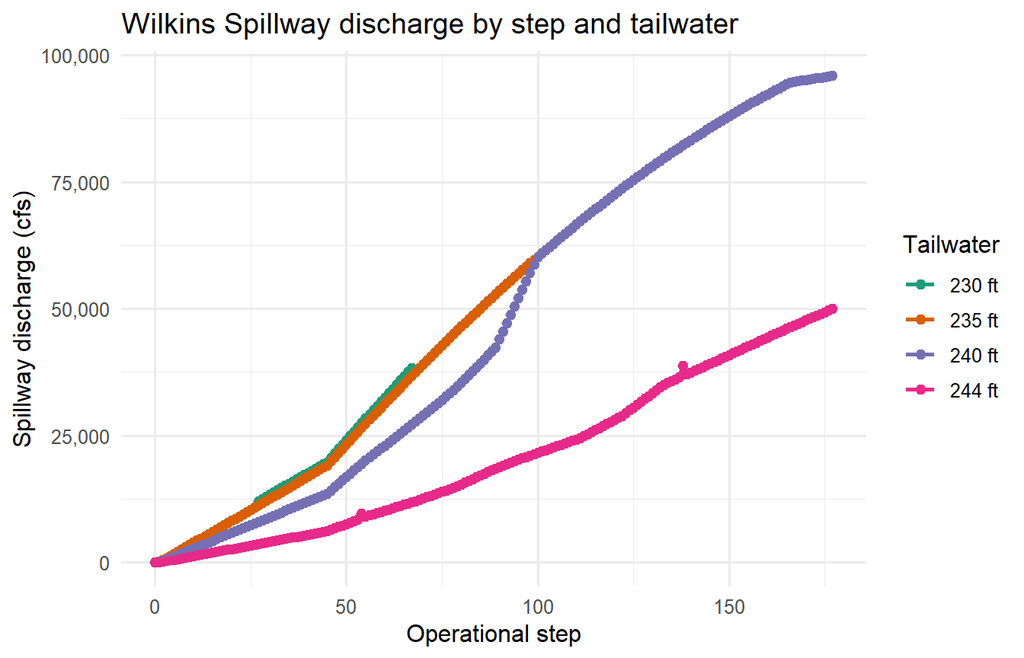

```r
gate_discharge_long <- gate_schedule_lookup %>%
  select(STEP, D_230, D_235, D_240, D_244) %>%
  tidyr::pivot_longer(
    cols      = starts_with("D_"),
    names_to  = "Tailwater_band",
    values_to = "Discharge_cfs"
  ) %>%
  mutate(
    Tailwater_band = factor(
      Tailwater_band,
      levels = c("D_230", "D_235", "D_240", "D_244"),
      labels = c("230 ft", "235 ft", "240 ft", "244 ft")
    )
  )

ggplot(gate_discharge_long,
       aes(x = STEP, y = Discharge_cfs, color = Tailwater_band)) +
  geom_line(linewidth = 1) +
  geom_point(size = 2) +
  scale_y_continuous(labels = scales::comma) +
  scale_color_brewer(palette = "Dark2", name = "Tailwater") +
  labs(
    title = "Wilkins Spillway discharge by step and tailwater",
    x     = "Operational step",
    y     = "Spillway discharge (cfs)"
  ) +
  theme_minimal(base_size = 12) +
  theme(legend.position = "right")
```

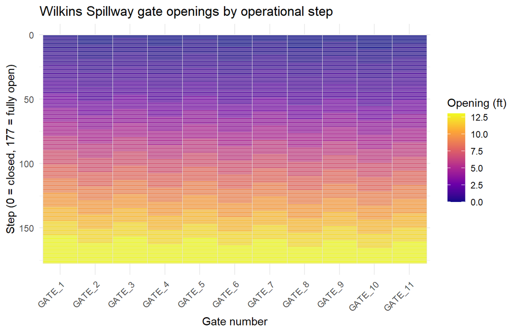

```r
gate_heat <- gate_schedule_lookup %>%
  filter(STEP > 0) %>%              # drop step 0 if present
  select(STEP, all_of(gate_keys)) %>%
  pivot_longer(
    cols      = all_of(gate_keys),
    names_to  = "Gate",
    values_to = "Opening_ft"
  ) %>%
  mutate(
    Gate = factor(Gate, levels = paste0("GATE_", 1:11))
  )

ggplot(gate_heat,
       aes(x = Gate, y = STEP, fill = Opening_ft)) +
  geom_tile(color = "grey90") +
  scale_fill_viridis_c(option = "C", na.value = "white") +
  scale_y_reverse() +
  labs(
    title = "Wilkins Spillway gate openings by operational step",
    x     = "Gate number",
    y     = "Step (0 = closed, 177 = fully open)",
    fill  = "Opening (ft)"
  ) +
  theme_minimal(base_size = 11) +
  theme(
    axis.text.x  = element_text(angle = 45, hjust = 1),
    legend.position = "right"
  )
```

### 2.2 Wilkins capacity curve

```r
capacity_curve <- tibble(
  Elevation_ft   = c(243, 244, 245, 246, 247),
  Storage_ac_ft  = c(12771.5, 14946.5, 17294, 19820, 22864.5)
)

capacity_curve
```

```
## # A tibble: 5 × 2
##   Elevation_ft Storage_ac_ft
##          <dbl>         <dbl>
## 1          243        12772.
## 2          244        14946.
## 3          245        17294
## 4          246        19820
## 5          247        22864.
```

The capacity curve links pool elevation to storage and is used to determine how much volume is available for ramp‑down before reaching the minimum navigation pool. For a given starting elevation, the dashboard converts to storage using this curve, subtracts the volume required to execute the planned ramp‑down, then converts back to a final elevation. If the requested ecological ramp‑down would consume more than the available storage above the navigation minimum, the operation becomes “navigation‑limited” and the duration is shortened accordingly.

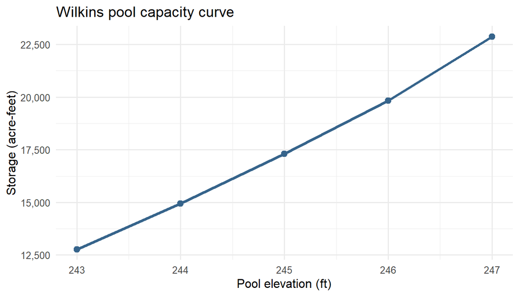

```r
ggplot(capacity_curve,
       aes(x = Elevation_ft, y = Storage_ac_ft)) +
  geom_line(color = "steelblue4", linewidth = 1.3) +
  geom_point(color = "steelblue4", size = 2.5) +
  scale_y_continuous(labels = comma) +
  labs(
    title = "Wilkins pool capacity curve",
    x     = "Pool elevation (ft)",
    y     = "Storage (acre-feet)"
  ) +
  theme_minimal(base_size = 12)
```

### 2.3 Nettleton depth regression coefficients

```r
NETT_INTERCEPT   <- -0.4386
NETT_BETA_FULTON <-  0.002816   # ft per cfs at Fulton
NETT_BETA_SPILL  <-  0.001131   # ft per cfs spillway discharge

c(
  intercept    = NETT_INTERCEPT,
  beta_fulton  = NETT_BETA_FULTON,
  beta_spill   = NETT_BETA_SPILL
)
```

```
##   intercept beta_fulton  beta_spill
##   -0.438600    0.002816    0.001131
```

## 3. Spillway discharge calculation

### 3.1 Tailwater interpolation

```r
get_step_discharge <- function(step_num, tailwater_ft) {
  if (step_num == 0) return(0)
  row <- gate_schedule_lookup %>% filter(STEP == step_num)
  if (nrow(row) == 0) return(0)

  if (tailwater_ft >= 215 && tailwater_ft <= 230) {
    if (!is.na(row$D_215_230)) return(row$D_215_230)
  }

  d_vals <- c(row$D_230, row$D_235, row$D_240, row$D_244)
  interp_pts <- tibble(
    tw  = c(230, 235, 240, 244),
    dis = d_vals
  ) %>% filter(!is.na(dis))

  if (nrow(interp_pts) < 2) return(0)

  approx_fun <- approxfun(interp_pts$tw, interp_pts$dis, rule = 2)
  approx_fun(tailwater_ft)
}

# Example: Step 10 at tailwater 238 ft
get_step_discharge(10, 238)
```

```
## [1] 3226.4
```

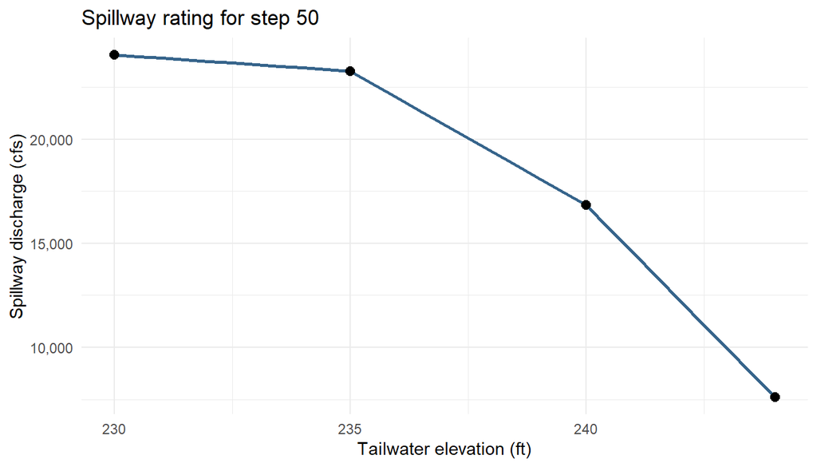

```r
example_step <- 50            # pick any step you care about
tw_seq       <- seq(230, 244, by = 0.5)

interp_df <- tibble(
  Tailwater_ft   = tw_seq,
  Discharge_cfs  = purrr::map_dbl(
    tw_seq,
    ~ get_step_discharge(example_step, .x)
  )
)

# discrete table values for that step

pts_df <- gate_schedule_lookup %>%
  filter(STEP == example_step) %>%
  select(D_230, D_235, D_240, D_244) %>%
  pivot_longer(
    everything(),
    names_to  = "col",
    values_to = "Discharge_cfs"
  ) %>%
  mutate(
    Tailwater_ft = c(230, 235, 240, 244)
  ) %>%
  filter(!is.na(Discharge_cfs))

ggplot() +
  geom_line(
    data = interp_df,
    aes(x = Tailwater_ft, y = Discharge_cfs),
    color = "steelblue4",
    linewidth = 1
  ) +
  geom_point(
    data = pts_df,
    aes(x = Tailwater_ft, y = Discharge_cfs),
    size = 2.5,
    color = "black"
  ) +
  labs(
    title = paste("Spillway rating for step", example_step),
    x     = "Tailwater elevation (ft)",
    y     = "Spillway discharge (cfs)"
  ) +
  scale_y_continuous(labels = scales::comma) +
  theme_minimal(base_size = 11)
```

Points mark the tabulated Wilkins rating for the selected step at 230, 235, 240, and 244 ft tailwater; the blue line shows the linear interpolation used to estimate discharge at intermediate tailwaters. The same interpolation is applied inside the dashboard whenever a user supplies a tailwater elevation between 230 and 244 ft.

### 3.2 Recognizing the current step from gate telemetry

```r
calc_q_from_gates <- function(g1, g2, g3, g4, g5, g6, g7, g8, g9, g10, g11, tailwater_ft) {
  observed_gates <- c(g1, g2, g3, g4, g5, g6, g7, g8, g9, g10, g11)
  if (all(is.na(observed_gates) | observed_gates == 0)) {
    return(list(step = 0, discharge = 0, distance = 0))
  }

  gate_cols_used <- gate_keys[-7]

  distances <- gate_schedule_lookup %>%
    filter(STEP > 0) %>%
    rowwise() %>%
    mutate(
      distance = sqrt(sum((c_across(all_of(gate_cols_used)) - observed_gates[-7])^2, na.rm = TRUE))
    ) %>%
    ungroup()

  best_match <- distances %>% slice_min(distance, n = 1, with_ties = FALSE)

  list(
    step      = best_match$STEP,
    discharge = get_step_discharge(best_match$STEP, tailwater_ft),
    distance  = best_match$distance
  )
}

# Example gate pattern (roughly Step 10)
example <- calc_q_from_gates(
  g1 = 0.5, g2 = 0.5, g3 = 0.5, g4 = 0.5, g5 = 0.5, g6 = 0.5,
  g7 = 0.0, g8 = 0.0, g9 = 0.5, g10 = 0.0, g11 = 0.5,
  tailwater_ft = 238
)
example
```

```
## $step
## [1] 10
##
## $discharge
## [1] 3226.4
##
## $distance
## [1] 0
```

## 4. Live data, trends, and risk flags

```r
calculate_trend <- function(df, val_col) {
  if (is.null(df) || nrow(df) == 0) return(list(current = NA, trend = NA))
  if (!val_col %in% names(df))    return(list(current = NA, trend = NA))

  df <- df %>% arrange(dateTime)
  current_row <- tail(df, 1)
  past_time   <- current_row$dateTime - hours(6)
  past_row    <- df %>% filter(dateTime <= past_time) %>% tail(1)

  current_val <- suppressWarnings(as.numeric(current_row[[val_col]]))
  trend_val <- if (nrow(past_row) > 0 && !is.na(past_row[[val_col]])) {
    suppressWarnings(as.numeric(current_row[[val_col]]) - as.numeric(past_row[[val_col]]))
  } else {
    NA
  }

  list(current = current_val, trend = trend_val)
}

get_trend_word <- function(trend_val) {
  if (is.na(trend_val))       return("stable")
  if (trend_val >  0.05)      return("rising")
  if (trend_val < -0.05)      return("falling")
  "stable"
}
```

## 5. Nettleton depth prediction

```r
predict_nettleton_depth <- function(flow_fulton_cfs, spillway_cfs) {
  depth <- NETT_INTERCEPT +
    NETT_BETA_FULTON * flow_fulton_cfs +
    NETT_BETA_SPILL  * spillway_cfs
  pmax(0, depth)
}

predict_nettleton_depth(5000, 3000)
```

```
## [1] 17.0344
```

```r
total_depth_drop <- function(spillway_start_cfs) {
  NETT_BETA_SPILL * spillway_start_cfs
}

total_depth_drop(3000)
```

```
## [1] 3.393
```

## 6. Ramp‑down planning math

```r
compute_ideal_duration <- function(Q_start, max_rate_ft_per_hr) {
  total_drop <- total_depth_drop(Q_start)
  max(1, total_drop / max_rate_ft_per_hr)
}

compute_ideal_duration(Q_start = 3000, max_rate_ft_per_hr = 0.10)
```

```
## [1] 33.93
```

```r
build_step_sequence <- function(S_start, target_steps) {
  num_intervals <- min(S_start, target_steps)
  unique(round(seq(S_start, 0, length.out = num_intervals + 1)))
}

build_step_sequence(14, 4)
```

```
## [1] 14 10  7  4  0
```

```r
compute_ideal_volume_af <- function(S_start, tw_ft, target_steps, T_ideal) {
  step_sequence <- build_step_sequence(S_start, target_steps)
  num_intervals <- length(step_sequence) - 1

  sum_q <- 0
  for (i in 1:num_intervals) {
    sum_q <- sum_q + get_step_discharge(step_sequence[i], tw_ft)
  }

  T_ideal * (sum_q * 3600) / (num_intervals * 43560)
}

compute_ideal_volume_af(
  S_start      = 14,
  tw_ft        = 220,
  target_steps = 4,
  T_ideal      = compute_ideal_duration(3000, 0.10)
)
```

```
## [1] 9489.885
```

```r
storage_from_elev <- function(H_ft) {
  approx(capacity_curve$Elevation_ft, capacity_curve$Storage_ac_ft,
         xout = H_ft, rule = 2)$y
}

elev_from_storage <- function(V_af) {
  approx(capacity_curve$Storage_ac_ft, capacity_curve$Elevation_ft,
         xout = V_af, rule = 2)$y
}

H0    <- 245.0
H_nav <- 244.5

V0    <- storage_from_elev(H0)
Vnav  <- storage_from_elev(H_nav)
Vmax  <- max(0, V0 - Vnav)

c(H0 = H0, H_nav = H_nav, V0 = V0, Vnav = Vnav, Vmax = Vmax)
```

```
##       H0    H_nav       V0     Vnav     Vmax
##   245.00   244.50 17294.00 16120.25  1173.75
```

```r
apply_nav_constraint <- function(S_start, tw_ft, target_steps,
                                 Q_start, H0, H_nav, max_rate_ft_per_hr) {
  T_ideal <- compute_ideal_duration(Q_start, max_rate_ft_per_hr)
  V_ideal <- compute_ideal_volume_af(S_start, tw_ft, target_steps, T_ideal)

  V0   <- storage_from_elev(H0)
  Vnav <- storage_from_elev(H_nav)
  Vmax <- max(0, V0 - Vnav)

  step_sequence <- build_step_sequence(S_start, target_steps)
  num_intervals <- length(step_sequence) - 1
  sum_q <- 0
  for (i in 1:num_intervals) {
    sum_q <- sum_q + get_step_discharge(step_sequence[i], tw_ft)
  }

  if (V_ideal <= Vmax) {
    T_final <- T_ideal
    V_final <- V_ideal
    nav_limited <- FALSE
  } else {
    V_final <- Vmax
    if (sum_q > 0 && V_final > 0) {
      T_final <- V_final * (num_intervals * 43560) / (sum_q * 3600)
    } else {
      T_final <- 0
    }
    nav_limited <- TRUE
  }

  delta_h    <- total_depth_drop(Q_start)
  rate_final <- if (T_final > 0) delta_h / T_final else NA_real_

  H_final <- elev_from_storage(V0 - V_final)

  list(
    T_ideal     = T_ideal,
    V_ideal     = V_ideal,
    T_final     = T_final,
    V_final     = V_final,
    nav_limited = nav_limited,
    rate_final  = rate_final,
    H_final     = H_final,
    drop_ft     = H0 - H_final
  )
}

plan_example <- apply_nav_constraint(
  S_start            = 14,
  tw_ft              = 220,
  target_steps       = 4,
  Q_start            = 3000,
  H0                 = 245.0,
  H_nav              = 244.5,
  max_rate_ft_per_hr = 0.10
)
plan_example
```

```
## $T_ideal
## [1] 33.93
##
## $V_ideal
## [1] 9489.885
##
## $T_final
## [1] 4.196609
##
## $V_final
## [1] 1173.75
##
## $nav_limited
## [1] TRUE
##
## $rate_final
## [1] 0.8085099
##
## $H_final
## [1] 244.5
##
## $drop_ft
## [1] 0.5
```

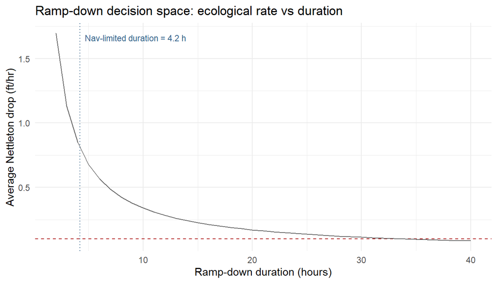

```r
# total Nettleton drop if spillway goes from Q_start to 0

delta_h <- total_depth_drop(spillway_start_cfs = 3000)
# or just:
delta_h <- total_depth_drop(3000)

# candidate durations spanning shorter/longer than ideal

cand_T <- seq(2, 40, by = 1)

dec_df <- tibble(
  T_hours          = cand_T,
  eco_rate_ft_hr   = delta_h / T_hours,
  nav_feasible     = T_hours >= plan_example$T_final  # anything shorter than nav-limited T_final would exceed available storage
)

ggplot(dec_df,
       aes(x = T_hours, y = eco_rate_ft_hr)) +
  geom_hline(
    yintercept = 0.10,
    linetype = "dashed",
    color = "firebrick"
  ) +
  geom_line(color = "grey40") +
  geom_vline(
    xintercept = plan_example$T_final,
    color = "steelblue4",
    linetype = "dotted"
  ) +
  annotate("text",
           x = plan_example$T_final,
           y = max(dec_df$eco_rate_ft_hr),
           label = sprintf("Nav-limited duration = %.1f h", plan_example$T_final),
           hjust = -0.05,
           vjust = 1.2,
           size = 3,
           color = "steelblue4") +
  labs(
    title = "Ramp-down decision space: ecological rate vs duration",
    x     = "Ramp-down duration (hours)",
    y     = "Average Nettleton drop (ft/hr)"
  ) +
  theme_minimal(base_size = 11)
```

This plot shows how the average Nettleton depth drop per hour decreases as the ramp‑down duration increases. The dashed red line is the ecological ramp‑rate target; the dotted blue line marks the navigation‑limited duration computed from the capacity curve. Any plan to the left of the blue line would overuse storage (violating navigation), and any plan above the red line would exceed the ecological ramp‑rate limit.

```r
build_ramp_scenarios <- function(S_start, tw_ft, target_steps,
                                 Q_start, T_final_hours,
                                 fulton_flow_eff = 4000) {
  start_time   <- floor_date(Sys.time(), "hour")
  duration_sec <- T_final_hours * 3600

  sudden <- tibble(
    Time      = c(start_time - hours(1), start_time, start_time + seconds(60), start_time + seconds(duration_sec)),
    Discharge = c(Q_start, Q_start, 0, 0),
    STEP      = c(S_start, S_start, 0, 0),
    Scenario  = "Sudden Closure (High Risk)"
  )

  if (S_start == 0 || duration_sec == 0) {
    proposed <- sudden %>%
      mutate(Scenario = "Gradual Ramp-Down (Safe/Best Available)")
  } else {
    step_sequence    <- build_step_sequence(S_start, target_steps)
    num_intervals    <- length(step_sequence) - 1
    time_spacing_sec <- duration_sec / num_intervals

    times <- c(start_time - hours(1))
    flows <- c(Q_start)
    steps <- c(S_start)
    current_t <- start_time

    for (i in seq_along(step_sequence)) {
      current_s <- step_sequence[i]
      current_q <- get_step_discharge(current_s, tw_ft)

      if (i > 1) {
        times <- c(times, current_t - seconds(1))
        flows <- c(flows, flows[length(flows)])
        steps <- c(steps, steps[length(steps)])
      }

      times <- c(times, current_t)
      flows <- c(flows, current_q)
      steps <- c(steps, current_s)
      current_t <- current_t + seconds(time_spacing_sec)
    }

    times <- c(times, current_t)
    flows <- c(flows, 0)
    steps <- c(steps, 0)

    proposed <- tibble(
      Time      = times,
      Discharge = flows,
      STEP      = steps,
      Scenario  = "Gradual Ramp-Down (Safe/Best Available)"
    )
  }

  bind_rows(sudden, proposed) %>%
    mutate(
      Predicted_Nettleton_Depth_ft =
        predict_nettleton_depth(
          flow_fulton_cfs = fulton_flow_eff,
          spillway_cfs    = Discharge
        )
    )
}

scenario_example <- build_ramp_scenarios(
  S_start         = 14,
  tw_ft           = 220,
  target_steps    = 4,
  Q_start         = get_step_discharge(14, 220),
  T_final_hours   = plan_example$T_final,
  fulton_flow_eff = 4000
)

head(scenario_example)
```

```
## # A tibble: 6 × 5
##   Time                Discharge  STEP Scenario            Predicted_Nettleton_…¹
##   <dttm>                  <dbl> <dbl> <chr>                                <dbl>
## 1 2026-09-23 12:00:00      5636    14 Sudden Closure (Hi…                   17.2
## 2 2026-09-23 13:00:00      5636    14 Sudden Closure (Hi…                   17.2
## 3 2026-09-23 13:01:00         0     0 Sudden Closure (Hi…                   10.8
## 4 2026-09-23 17:11:47         0     0 Sudden Closure (Hi…                   10.8
## 5 2026-09-23 12:00:00      5636    14 Gradual Ramp-Down …                   17.2
## 6 2026-09-23 13:00:00      5636    14 Gradual Ramp-Down …                   17.2
## # ℹ abbreviated name: ¹Predicted_Nettleton_Depth_ft
```

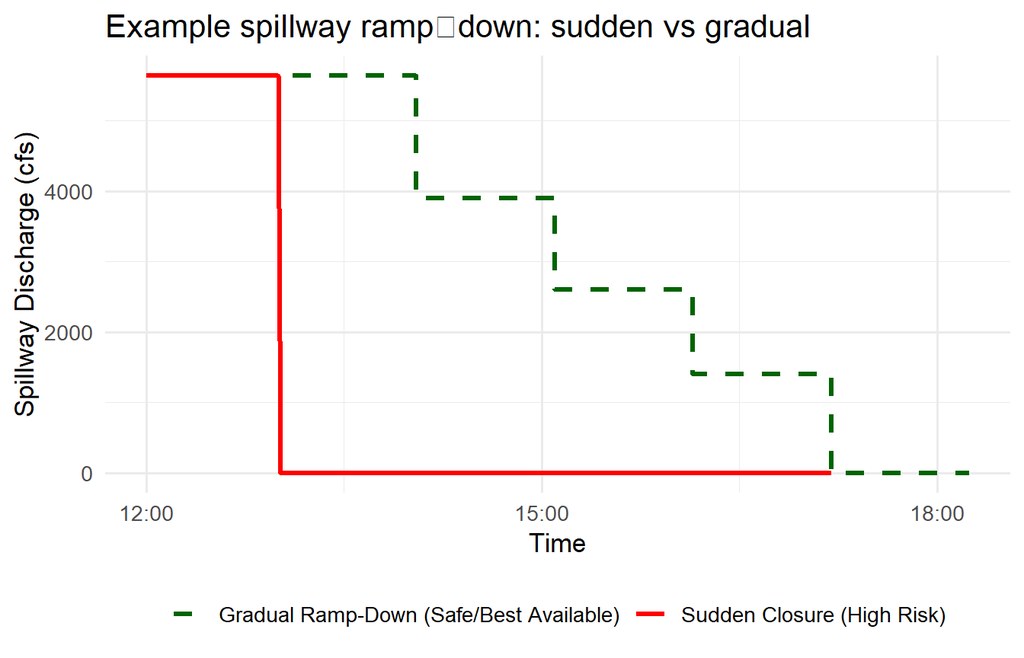

```r
ggplot(scenario_example,
       aes(x = Time, y = Discharge, color = Scenario, linetype = Scenario)) +
  geom_line(linewidth = 1.1) +
  scale_color_manual(values = c(
    "Sudden Closure (High Risk)"              = "red",
    "Gradual Ramp-Down (Safe/Best Available)" = "darkgreen"
  )) +
  scale_linetype_manual(values = c(
    "Sudden Closure (High Risk)"              = "solid",
    "Gradual Ramp-Down (Safe/Best Available)" = "dashed"
  )) +
  labs(
    title = "Example spillway ramp‑down: sudden vs gradual",
    x = "Time",
    y = "Spillway Discharge (cfs)"
  ) +
  theme_minimal(base_size = 13) +
  theme(legend.position = "bottom", legend.title = element_blank())
```

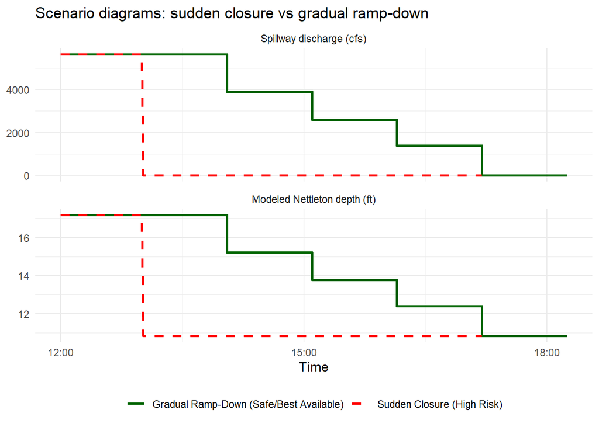

```r
scenario_long <- scenario_example %>%
  select(Time, Scenario, Discharge, Predicted_Nettleton_Depth_ft) %>%
  pivot_longer(
    cols      = c(Discharge, Predicted_Nettleton_Depth_ft),
    names_to  = "Quantity",
    values_to = "Value"
  ) %>%
  mutate(
    Quantity = factor(Quantity,
                      levels = c("Discharge", "Predicted_Nettleton_Depth_ft"),
                      labels = c("Spillway discharge (cfs)",
                                 "Modeled Nettleton depth (ft)"))
  )

ggplot(scenario_long,
       aes(x = Time, y = Value, color = Scenario, linetype = Scenario)) +
  geom_line(linewidth = 1.0) +
  facet_wrap(~ Quantity, ncol = 1, scales = "free_y") +
  scale_color_manual(values = c(
    "Sudden Closure (High Risk)"              = "red",
    "Gradual Ramp-Down (Safe/Best Available)" = "darkgreen"
  )) +
  scale_linetype_manual(values = c("solid", "dashed")) +
  labs(
    title = "Scenario diagrams: sudden closure vs gradual ramp-down",
    x     = "Time",
    y     = NULL
  ) +
  theme_minimal(base_size = 11) +
  theme(legend.position = "bottom", legend.title = element_blank())
```